# Scales

September 2021

## Information processing

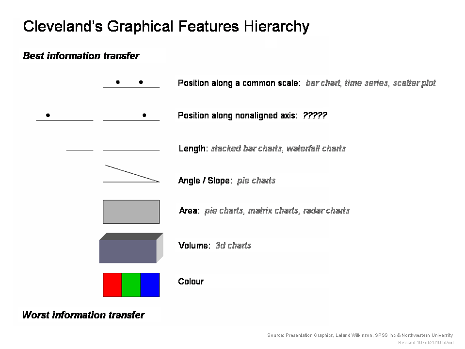

- Image downloaded from defunct post [This link no longer works ☹](http://sfew.websitetoolbox.com/post/clevelands-graphical-features-hierarchy-4598555)
- [Some information from flowingdata](https://flowingdata.com/2010/03/20/graphical-perception-learn-the-fundamentals-first/)

## Scales

- The top of the hierarchy involves putting things on scales
- But what scale do we use?
  - Are our data anchored to zero?
    - If so, are we interested in differences or ratios?
  - Are they anchored somewhere else?

## Anchors

## Utter problem algae

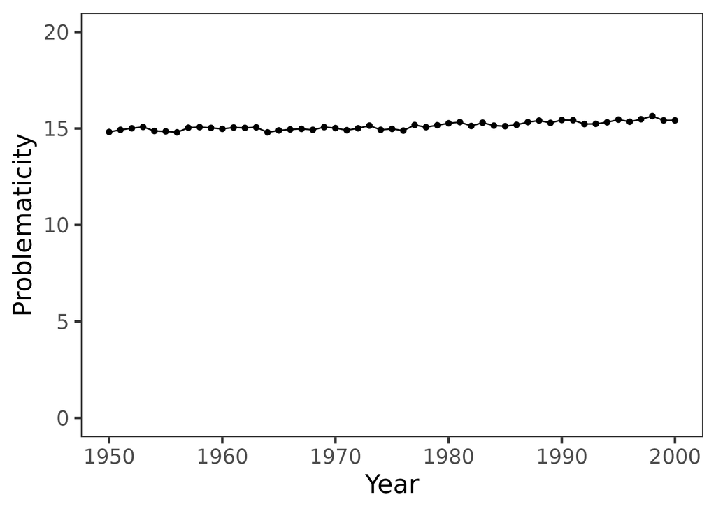

## Utter problem algae

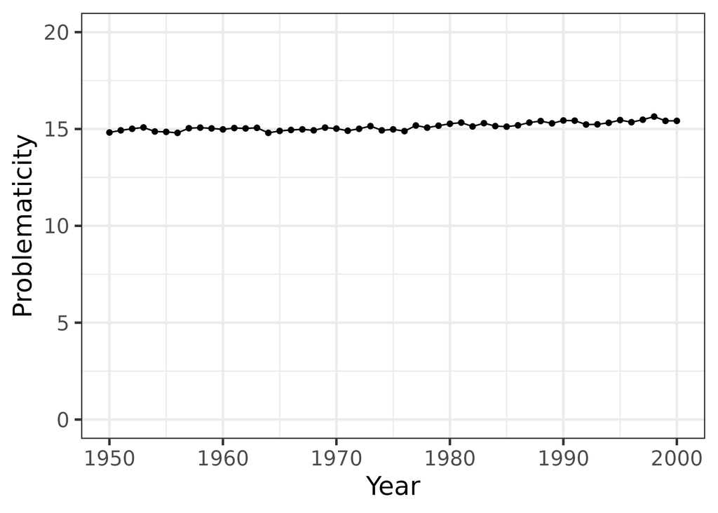

## Utter problem algae

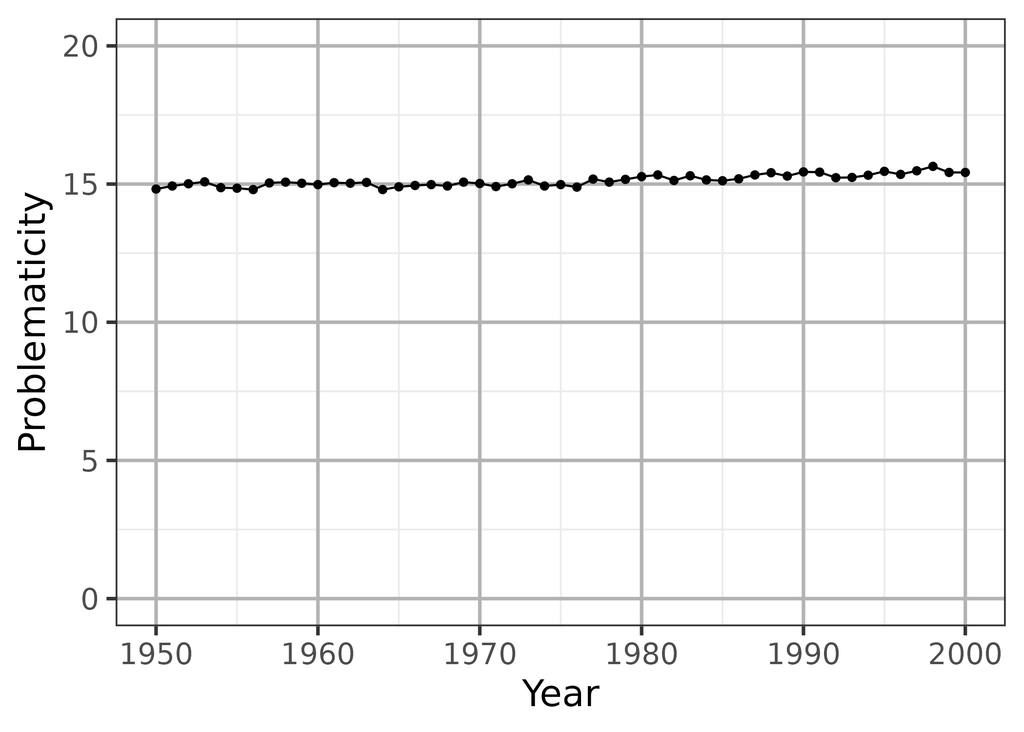

## Global temperature

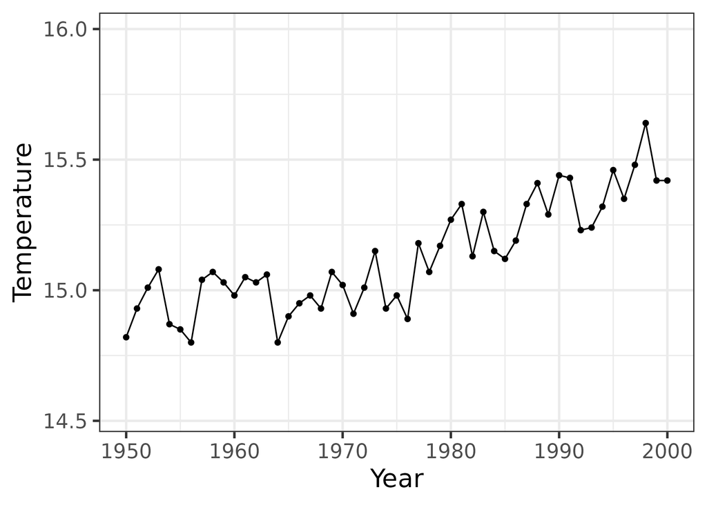

## Global temperature

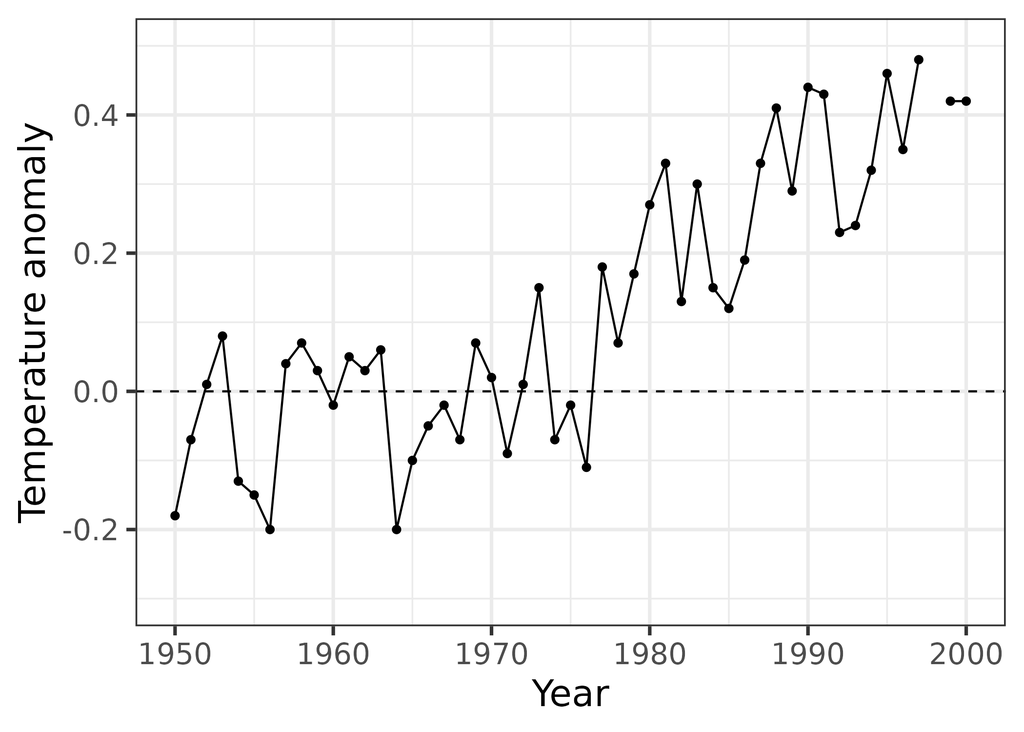

## Global temperature

- [Data](https://datahub.io/core/global-temp/r/annual.csv)
- Code: clean; plot
- Dushoff craziness! [shellpipes](https://dushoff.github.io/shellpipes/)

## Magazine circulation (advertisement)

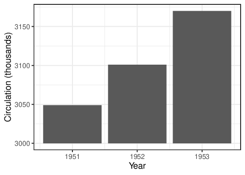

## Magazine circulation (absolute amount)

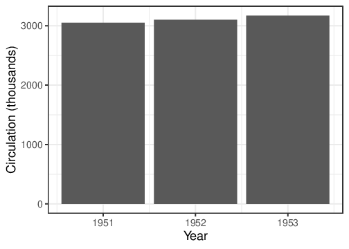

## Magazine circulation (trend)

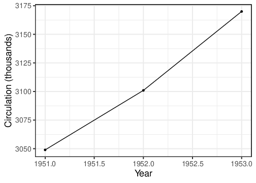

## Magazine circulation (trend)

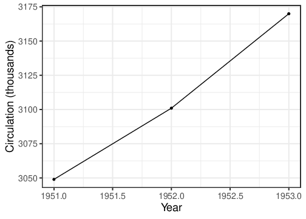

* Data * Code

## Area and volume

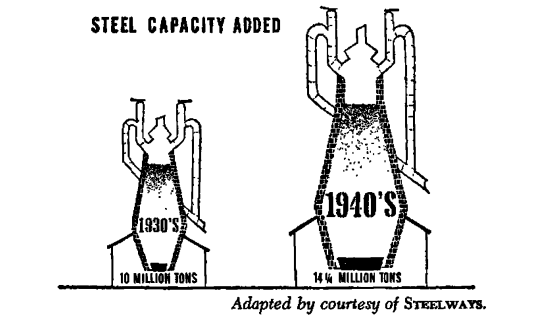

From [How to Lie with Statistics](https://en.wikipedia.org/wiki/How_to_Lie_with_Statistics)

## Advertisement lessons

- Use area to indicate fair comparisons
  - On a physical scale
- Areas that can be compared linearly should be preferred
  - Depends on importance of feature
- Avoid using (or hinting at) volume

## Ratio scaling

## Physical quantities

- 1 is to 10 as 10 is to what?
- The **log scale** is often good for concrete quantities:
  - When zero means zero
  - When we are thinking about things that might be added together
    - But *not* when we actually want to add them together!

## Provinces of Canada

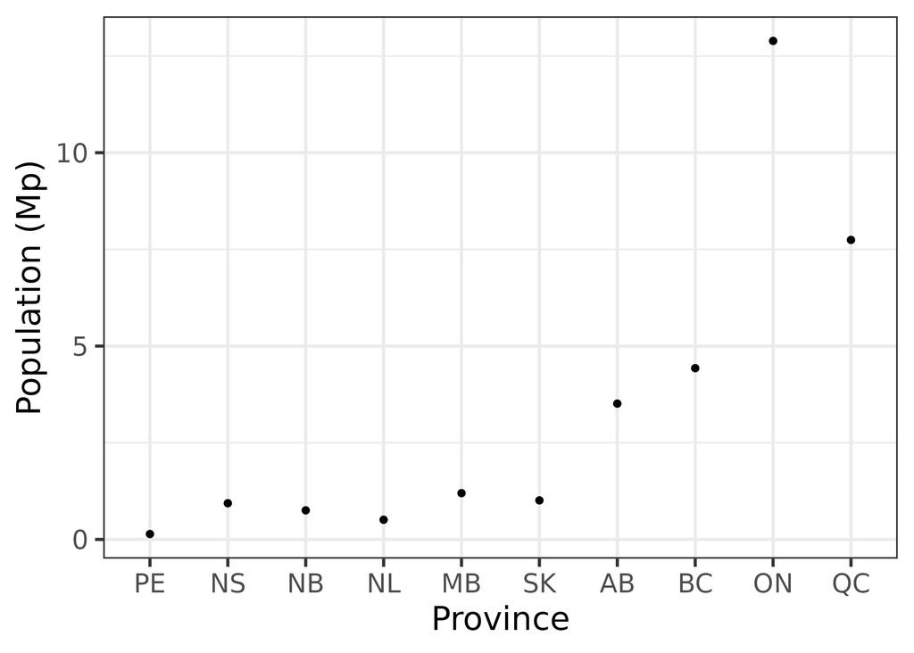

## Provinces of Canada

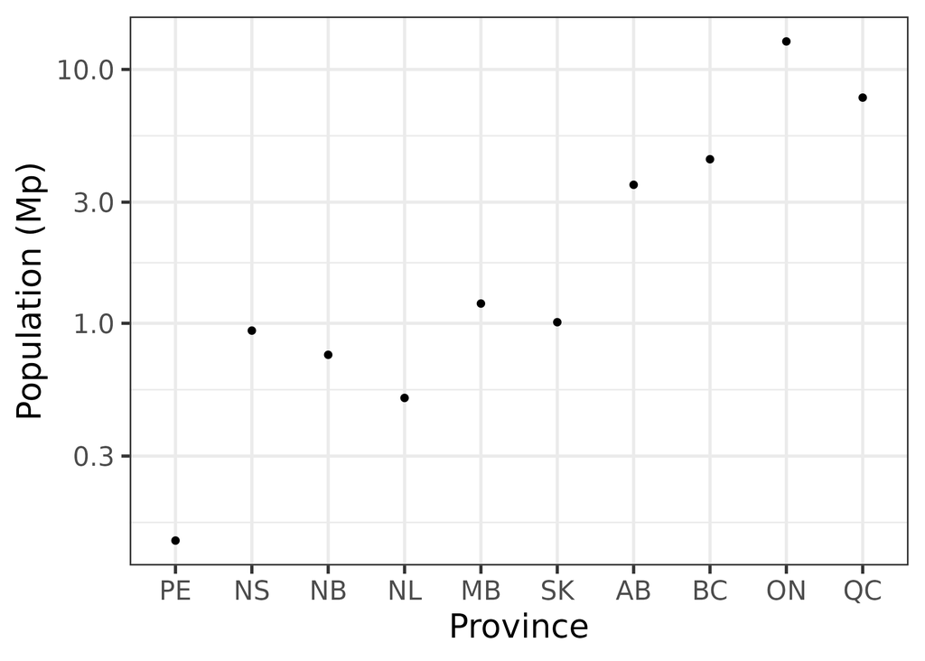

## Provinces of Canada

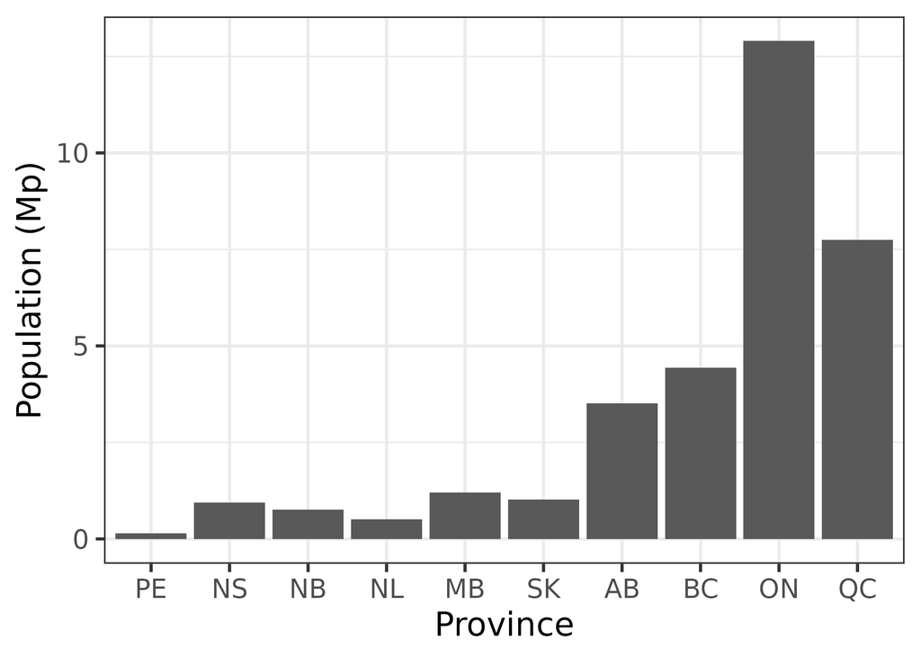

## Provinces of Canada

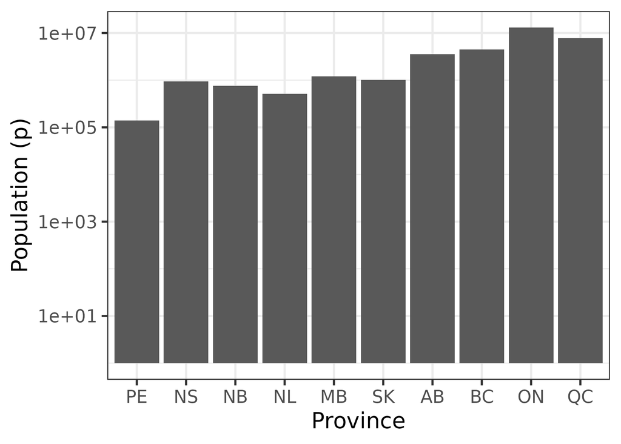

## Provinces of Canada

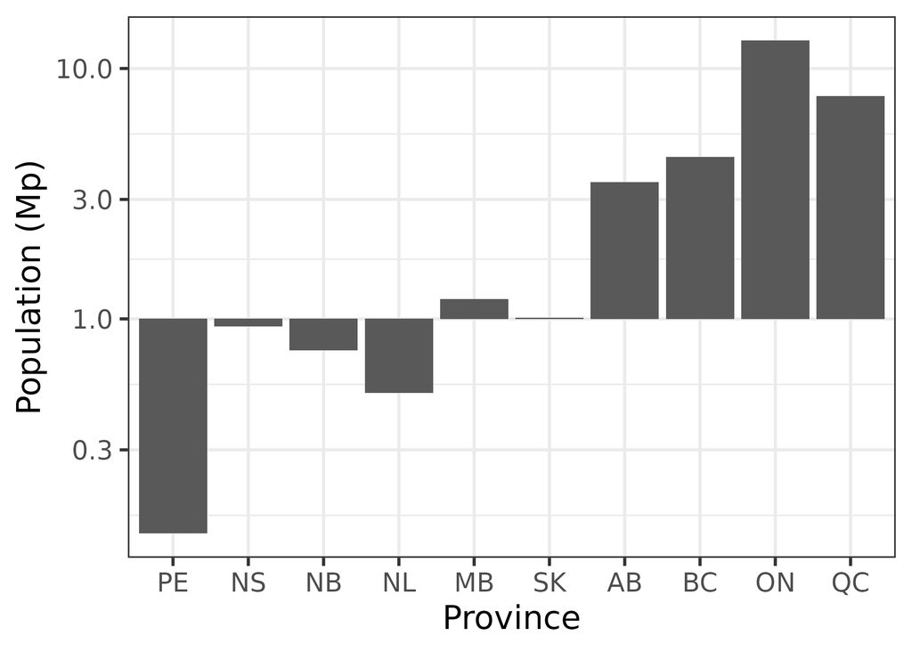

## Provinces of Canada

- Code: clean; plot
- Data

## Coronavirus incidence

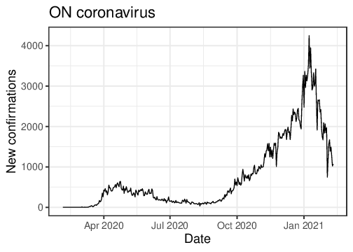

## Coronavirus incidence

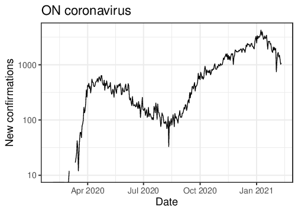

## Coronavirus incidence

- Code: clean; plot
- Data

## Odds-ratio scaling

## Probabilities

- 1% is to 10% as 10% is to what?
- There is a simple, good answer
  - No single answer will always be best

## Example

- 20% of the adult population is unvaccinated, but they account for 60% of clinical diagnoses
- How much greater is their risk?

## Odds ratios

- The *odds* of an adult being unvaccinated is the ratio of the probabilities unvaccinated:vaccinated
  - 0.2/0.8 = 1/4
- The odds of a diagnosee being unvaccinated is
  - 0.6/0.4 = 1.5
  - The odds *ratio* is 6 – that’s the correct measure of relative risk
  - You can work this out the long way
- Odds are a natural basis for doing calculations with probabilities
  - These calculations are usually ratio-based
- Therefore: a good scale for many probability questions is the log-odds (or *logit*) scale

## Probabilities

- 1% is to 10% as 10% is to …
- There is a simple, good answer
  - No single answer will always be best
- Odds scale: 1/99 is to 1/9 as 1/9 is to 11/9
  - Probability scale … 55%
  - Has a concrete meaning, for example screening tests:
  - if 1% prevalence implies 10% of positives are true, then:
  - Has a concrete meaning; if 10% prevalence implies 55% of positives are true

## Coronavirus vaccination

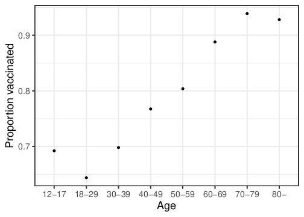

## Coronavirus vaccination

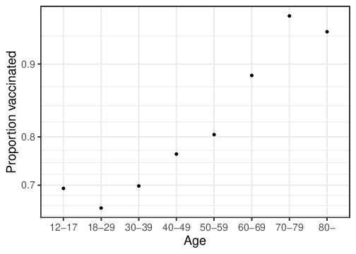

## Coronavirus vaccination

- Code
- Data

## Transformation lessons

- Transformations don’t make your data less real
- Different perspectives illuminate different questions
- Use visual clues to suggest whether your scales are additive